# Wind Farm Analysis

Mert Güvey

2025-07-04

```r
library(data.table)
library(ggplot2)
library(patchwork)
```

```r
import_initial <- fread("Data_Wind.csv", colClasses = c(index = "POSIXct", site = "factor"))
metadata_farms <- fread("Metadata.csv", colClasses = c(id = "factor"))
```

```r
panel_farms <-
  copy(import_initial) |>
    setnames(
      old = colnames(import_initial)[3:8],
      new = c("power", "temp", "angle", "rotor_speed", "direction", "wind_speed")
      ) |>
    _[
      expand.grid(
        index =
          seq.POSIXt(
            from = import_initial[, min(index)],
            to = import_initial[, max(index)],
            by = "hour"
            ),
        site =
          as.factor(1:4)
      ),
      on = .NATURAL
      ] |>
    _[,
      `:=`(
        year = year(index),
        month = month(index),
        m_day = mday(index),
        hour = hour(index),
        wind = direction | wind_speed
        )
      ]
```

```r
panel_farms |>
  _[
    metadata_farms[, list(id, cap = `Capacity KWh`)],
    `:=`(
      cap_util = round(pmax(0, power) / cap, 2),
      time_of_day =
        fcase(
          hour %in% c(22, 23, 0, 1, 2, 3), "10PM-3AM",
          hour %in% 4:9, "4AM-9AM",
          hour %in% 10:15, "10AM-3PM",
          hour %in% 16:21, "4PM-9PM"
          )
      ),
    on = "site == id"
    ] |>
  _[,
    time_of_day := ordered(time_of_day, levels = c("4AM-9AM", "10AM-3PM", "4PM-9PM", "10PM-3AM"))
    ]
```

```r
panel_rolling <-
  panel_farms |>
    _[
      index > as.POSIXct("2021-04-15", tz = "GMT"),
      list(
        index,
        temp_daily = frollmean(temp, n = 24L, align = "right", na.rm = TRUE, hasNA = TRUE),
        temp_seasonal = frollmean(temp, n = 720L, align = "right", na.rm = TRUE, hasNA = TRUE),
        wind_daily = frollmean(wind_speed, n = 24L, align = "right", na.rm = TRUE, hasNA = TRUE),
        wind_seasonal = frollmean(wind_speed, n = 720L, align = "right", na.rm = TRUE, hasNA = TRUE),
        power_daily = scale(frollsum(power, n = 24L, align = "right", na.rm = TRUE, hasNA = TRUE), center = FALSE),
        speed_daily = scale(frollmean(rotor_speed, n = 24L, align = "right", na.rm = TRUE, hasNA = TRUE), center = FALSE)
        ),
      by = site
      ]
```

```r
panel_farms |>
  _[
    wind == FALSE,
    direction := NA
    ] |>
  _[,
    cardinality :=
      fcase(
        direction < 45, "E",
        direction < 90, "NE",
        direction < 135, "N",
        direction < 180, "NW",
        direction < 225, "W",
        direction < 270, "SW",
        direction < 315, "S",
        direction < 360, "SE"
        )
    ] |>
  _[,
    cardinality := ordered(cardinality, levels = c("E", "NE", "N", "NW", "W", "SW", "S", "SE"))
    ]
```

## Introduction

In their article *Historical Hourly Information of Four European Wind Farms for Wind Energy Forecasting and Maintenance*, Sanchez-Soriano et al. provide data regarding four European wind farms and elaborate on the methodology of collection, modelling and possible uses. Looking at such parameters as wind speed, rotor speed, and power generation, I make comparisons on the basis of site, time of day, wind direction etc. and aim to gain a better understanding of the factors involved in achieving optimal capacity utilization.

The four sites have differing turbine counts and capacities. They are also located relatively close together, despite being on three different countries. Sites 1 and 2 have low turbine counts but high per-turbine capacity, whereas site 3 has many low-capacity turbines. Site 4 has more turbines and capacity than sites 1 and 2, but low per-turbine capacity.

```r
metadata_farms[, list(ID = id, `Turbine Count` = Wind_generator_number, `Capacity KWh`, Latitude = latitude, Longitude = longitude, Jurisdiction = State, Country)]
```

```
##        ID Turbine Count Capacity KWh Latitude Longitude Jurisdiction Country
##    <fctr>         <int>        <num>    <num>     <num>       <char>  <char>
## 1:      1             7        20800 45.99930  6.640500 Haute-Savoie  France
## 2:      2             6        17400 46.08450  6.709800 Haute-Savoie  France
## 3:      3            20        38000 41.97745 -0.948125     Zaragoza   Spain
## 4:      4             8        21400 45.67840  8.128600       Biella   Italy
```

## Overview

Data has been collected over a period of three years from four wind farms in Europe [1], although significant gaps are present in the time series. From the end of December 2021 to the end of August 2022, no data is reported for any of the sites. The same is true for September 2023. For individual sites, missingness follows similar patterns among sites 1, 2 and 4; with the caveat that site 4 does not have any data available before April 14, 2021. Site 3 diverges from remaining sites on some individual missing timestamps, with an additional gap of one month during the period of March-April 2023. Although limitations imposed by missing periods is considerable, ample data is nevertheless available for all months and hours of day, making it possible to draw comparisons on the basis of season or time of day.

```r
lapply(split(panel_farms, ~ site), \(dt) visdat::vis_miss(dt[, list(wind)]))
```

```
## $`1`
```

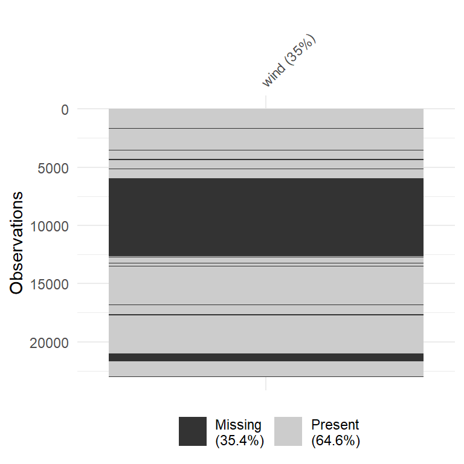

```
##
## $`2`
```

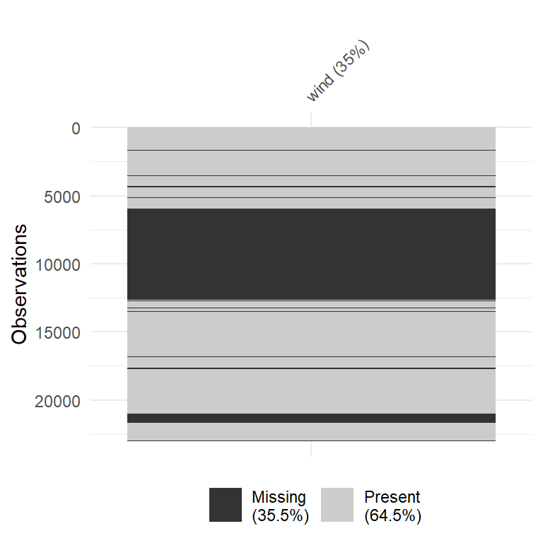

```
##
## $`3`
```

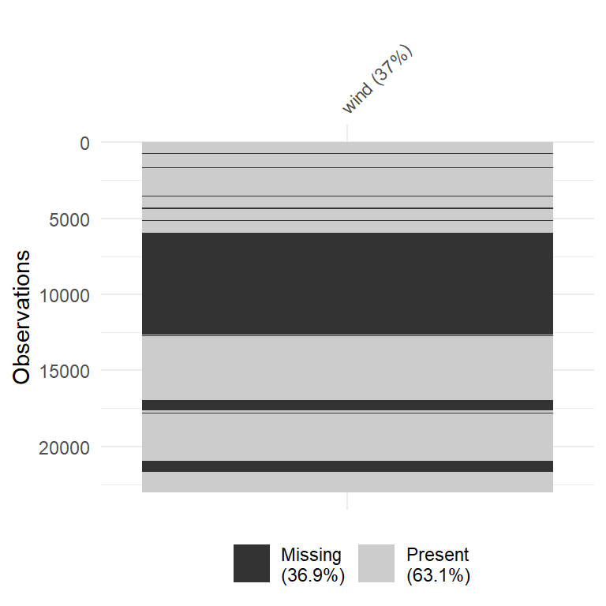

```
##
## $`4`
```

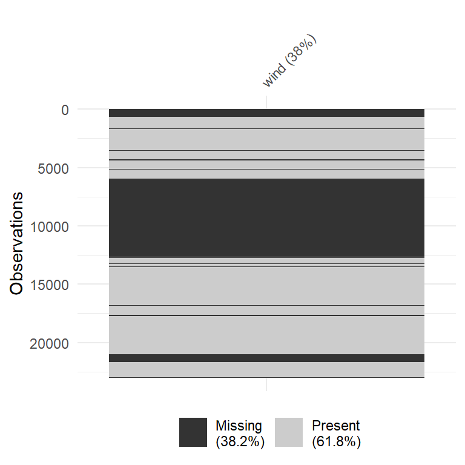

It appears that for site 4, a single value is provided for rotor speed and nacelle angle due to erroneous data collection or confidentiality reasons. I have taken care to exclude these values from summaries and general comparisons of said data. This restricts the ability to draw insights for the given site as well as the precision of the general conclusions, however we can roughly tell that the behavior is similar to those observed in sites 1 and 2, and prediction of these values might be a good motivator for further study.

```r
panel_farms |>
  _[
    site == 4,
    list(
      `Rotor Mode` = max(rotor_speed, na.rm = TRUE),
      `Nacelle Mode` = max(angle, na.rm = TRUE)
      )
    ]
```

```
##    Rotor Mode Nacelle Mode
##         <num>        <num>
## 1:   8.298556      232.311
```

```r
panel_farms |>
  _[
    !is.na(wind),
    list(
      `Non-Positive Readings` = sum(power <= 0, na.rm = TRUE) / .N,
      `Power Drawn` = sum(fifelse(power > 0, 0, power))
      ),
    by = list(Site = site)
    ]
```

```
##      Site Non-Positive Readings Power Drawn
##    <fctr>                 <num>       <num>
## 1:      1             0.1113650   -19593.54
## 2:      2             0.1543845   -22581.05
## 3:      3             0.1485176   -28764.80
## 4:      4             0.1045637   -13328.57
```

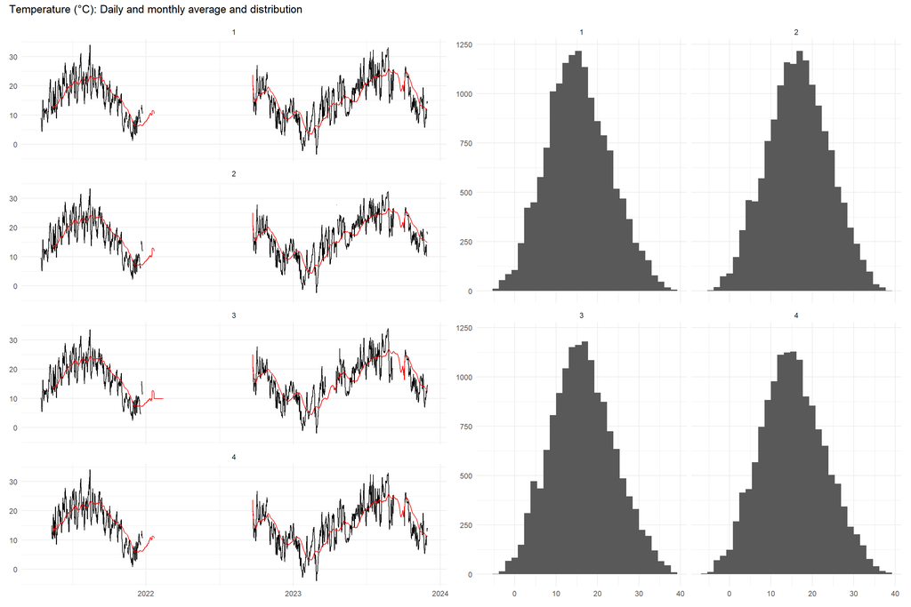

```r
panel_rolling |>
  _[,
    ggplot(
      data = .SD,
      mapping = aes(x = index)
      ) +
      geom_line(
        mapping = aes(y = temp_daily)
        ) +
      geom_line(
        mapping = aes(y = temp_seasonal),
        colour = "red"
        ) +
      facet_wrap(
        facets = vars(site), ncol = 1
        ) +
      labs(
        x = NULL,
        y = NULL
        ) +
      theme_minimal()
    ] -> temp_series_chart

panel_farms |>
  _[,
    ggplot(
      data = .SD
      ) +
      geom_histogram(
        mapping = aes(x = temp)
        ) +
      facet_wrap(
        facets = vars(site), nrow = 2
        ) +
      labs(
        x = NULL,
        y = NULL
        ) +
      theme_minimal()
    ] -> temp_dist_chart

temp_series_chart +
temp_dist_chart +
  plot_annotation(
    title = "Temperature (°C): Daily and monthly average and distribution"
    )
```

All sites are subject to similar temperatures and variations in temperature, and the values follow a roughly normal distribution. Overall there is not a significant difference to speak of between the sites, in the general picture as well as in daily or seasonal terms.

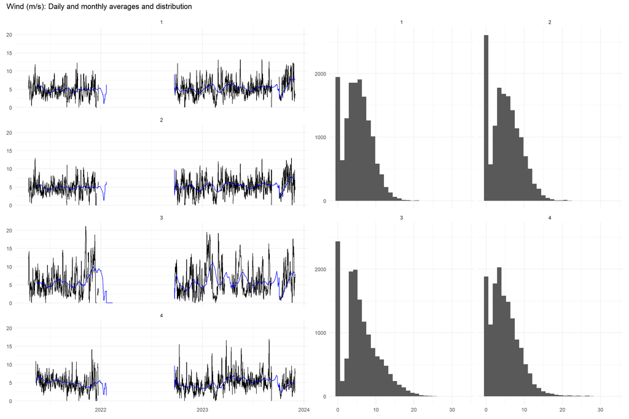

```r
panel_rolling |>
  _[,
    ggplot(
      data = .SD,
      mapping = aes(x = index)
      ) +
      geom_line(
        mapping = aes(y = wind_daily)
        ) +
      geom_line(
        mapping = aes(y = wind_seasonal),
        colour = "blue"
        ) +
      facet_wrap(
        facets = vars(site), ncol = 1
        ) +
      labs(
        x = NULL,
        y = NULL
        ) +
      theme_minimal()
    ] -> wind_series_chart

panel_farms |>
  _[,
    ggplot(
      data = .SD
      ) +
      geom_histogram(
        mapping = aes(x = wind_speed)
        ) +
      facet_wrap(
        facets = vars(site), nrow = 2
        ) +
      labs(
        x = NULL,
        y = NULL
        ) +
      theme_minimal()
    ] -> wind_dist_chart

wind_series_chart +
wind_dist_chart +
  plot_annotation(
    title = "Wind (m/s): Daily and monthly averages and distribution"
    )
```

With regard to wind speeds, site 3 in Spain differs from the rest as highly variable over time, and subject to greater oscillations and wind speed potential. It also has a very high number of non-windy readings. As wind farms positioned very close together and both in France, site 1 and site 2 are subject to very similar conditions, however it is to be noted that site 2 records significantly more non-windy hours than site 1. Site 4 in Italy follows similar trends as sites 1 and 2, but differs in the overall magnitudes of its values. It has a more peaked distribution with a fatter left tail. Overall it can be said that for windy hours, the magnitude is determined by a right-tailed distribution, which may be approximated by gamma distributions with differing parameters for each site.

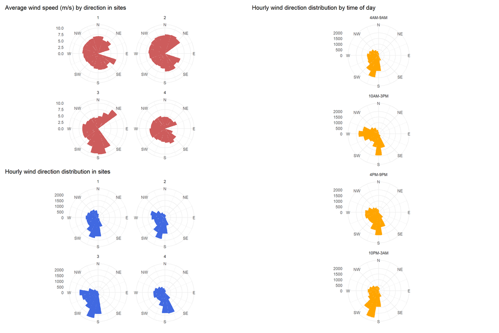

```r
panel_farms |>
  _[
    wind == TRUE,
    ggplot(
      data = .SD
      ) +
      stat_summary_bin(
        mapping = aes(x = direction, y = wind_speed), fun = "mean",
        geom = "col", fill = "indianred", binwidth = 18
        ) +
      scale_x_continuous(
        name = NULL,
        limits = c(0, 360),
        breaks = seq(from = 0, to = 315, by = 45),
        labels = cardinal_directions
        ) +
      coord_polar(
        start = 3 * pi / 2, direction = -1
        ) +
      facet_wrap(
        facets = vars(site), nrow = 2
        ) +
      labs(
        title = "Average wind speed (m/s) by direction in sites",
        y = NULL
        ) +
      theme_minimal() +
      theme(
        plot.title.position = "plot"
        )
    ] -> wind_speed_by_direction

panel_farms |>
  _[
    wind == TRUE,
    ggplot(
      data = .SD
      ) +
      geom_histogram(
        mapping = aes(x = direction), binwidth = 18, fill = "royalblue"
        ) +
      scale_x_continuous(
        name = NULL,
        limits = c(0, 360),
        breaks = seq(from = 0, to = 315, by = 45),
        labels = cardinal_directions
        ) +
      coord_polar(
        start = 3 * pi / 2, direction = -1
        ) +
      facet_wrap(
        facets = site, nrow = 2
        ) +
      labs(
        title = "Hourly wind direction distribution in sites",
        y = NULL
        ) +
      theme_minimal() +
      theme(
        plot.title.position = "plot",
        plot.caption.position = "plot",
        plot.caption = element_text(hjust = 0)
        )
    ] -> direction_dist_site

panel_farms |>
  _[
    wind == TRUE,
    ggplot(
      data = .SD
      ) +
      geom_histogram(
        mapping = aes(x = direction), binwidth = 18, fill = "orange"
        ) +
      scale_x_continuous(
        name = NULL,
        limits = c(0, 360),
        breaks = seq(from = 0, to = 315, by = 45),
        labels = cardinal_directions
        ) +
      coord_polar(
        start = 3 * pi / 2, direction = -1
        ) +
      facet_wrap(
        facets = time_of_day, ncol = 1
        ) +
      labs(
        title = "Hourly wind direction distribution by time of day",
        y = NULL
        ) +
      theme_minimal() +
      theme(
        plot.title.position = "plot",
        plot.caption.position = "plot",
        plot.caption = element_text(hjust = 0)
        )
    ] -> direction_dist_tod

wind_speed_by_direction +
direction_dist_site +
direction_dist_tod +
  plot_layout(
    design = c(area(1, 1), area(2, 1), area(1, 2, b = 2))
    )
```

The sites are predominantly subject to southbound winds, with a slant towards west in the case of sites 1 and 2, and east in the case of site 4. Wind speeds appear to be considerably higher for site 3, especially for those southbound. Other sites are less fortunate however, with their dominant southbound winds having even less force compared to other directions. The levels for site 4 further confirm its wind speeds are lowest among all sites. It seems that the sites are very episodically subject to strong eastbound winds, but this factors in little for the overall picture. One last thing to note is that site 2 is subject to more and stronger winds bound for northwest than site 1, highlighting the variability of wind direction even in smaller geographical scales.

## Rotor, Wind & Power

```r
panel_farms |>
  _[
    list(TRUE, as.factor(1:3)),
    ggplot(
      data = .SD
      ) +
      geom_point(
        mapping = aes(x = wind_speed, y = rotor_speed, colour = power)
        ) +
      scale_colour_continuous(
        name = NULL, guide = NULL, type = "viridis"
        ) +
      facet_wrap(
        facets = vars(site), ncol = 1
        ) +
      labs(
        x = "Wind m/s",
        y = "Rotor RPM"
        ) +
      theme_minimal(),
    on = list(wind, site)
    ] -> wind_rotor_dotplot
```

```r
panel_farms |>
  _[
    site != 4 & wind == TRUE,
    ggplot(
      data = .SD
      ) +
      stat_summary_2d(
        mapping = aes(x = wind_speed, y = rotor_speed, z = power),
        fun = "median"
        ) +
      stat_bin_2d(
        mapping =
          aes(
            label = after_stat(count), alpha = after_stat(count),
            x = wind_speed, y = rotor_speed,
            ),
        geom = "text", colour = "white", size = 3.5
        ) +
      scale_fill_continuous(
        name = "Power (kWh)", type = "viridis"
        ) +
      scale_alpha_continuous(
        name= NULL, guide = NULL
        ) +
      labs(
        x = "Wind m/s",
        y = "Rotor RPM"
        ) +
      theme_minimal() +
      theme(
        panel.grid = element_blank(),
        plot.title.position = "plot",
        legend.title = element_text(vjust = 1, size = 10),
        legend.position = "bottom",
        legend.key.height = rel(.5),
        legend.key.width = rel(2)
        )
     ] -> wind_rotor_heatmap
```

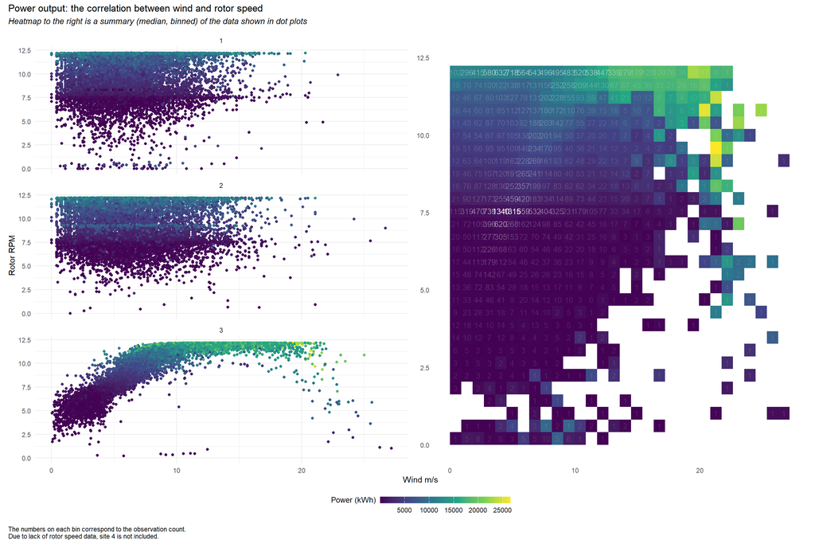

```r
wind_rotor_dotplot +
wind_rotor_heatmap +
  plot_annotation(
    title = "Power output: the correlation between wind and rotor speed",
    subtitle = "Heatmap to the right is a summary (median, binned) of the data shown in dot plots",
    caption =
      paste0(
        "The numbers on each bin correspond to the observation count.\n",
        "Due to lack of rotor speed data, site 4 is not included."
        )
    ) +
  plot_layout(
    guides = "collect",
    axes = "collect"
    ) &
  theme(
    legend.position = "bottom",
    plot.subtitle = element_text(face = "italic"),
    plot.caption = element_text(hjust = 0)
    )
```

It appears that the turbines in site 3 are of a different nature than those in sites 1 and 2. Whereas rotor speeds in sites 1 and 2 are little influenced by wind speed, there is a strong linear association in the case of site 3, subject to technical limitations. The difference seems to be that turbines in 1 and 2 are gearbox turbines, which do not require high wind speeds for high power output. In contrast, turbines in site 3 would be traditional designs with rotors that ramp up in response to increasing wind speeds. Turbines in the other sites seem to “kick in” under certain conditions, the presence of wind being only one of them. Gearbox turbines, while capable of generating power even in less windy climates, are more demanding in terms of maintenance than classic designs. Although site 4 is not included in this chart, the prevailing weather conditions, its generation profile and site characteristics lead us to conclude that it also houses gearbox turbines.

We see that site 3 can leverage its high capacity in higher speeds, and is the most responsive to wind speed. A linear relationship between wind speed and rotor speed can be observed up to 10 m/s, at which point the rotor is likely to hit its maximum speed of 12.5 RPM. This rotor speed is maintained up to a wind speed of 20 m/s, at which point turbines start to progressively drop out of operation. It is also notable that power output continues to increase with wind speed even as the rotor is operating at its maximum speed.

For sites 1 and 2, we notice rotor speed value agglomerations at the 7.5 RPM and 12.5 RPM marks. 12.5 RPM seems to be common across sites as the maximum threshold, whereas many 7.5 RPM values seem to be the result of forward-filling. This appears to be largely innocuous as the generation values are consistent with the value expected at those levels. There is also a streak of 9 RPM values in the case of site 2, with higher generation than normal. Overall it can be said that there is weak, if any, correlation between wind speed and rotor speed for those sites. On the other hand, the colors hint at a positive correlation between rotor speed and power output. Together with the clustering at the maximum of 12.5 RPM, it appears that these turbines have a desired operational state where they hit maximum rotor speed and realize most of their capacity. However, the gradual increase in generation from middling to maximum rotor speed levels indicates that interpolation is possible, it is just that these values are rare and seemingly transient.

```r
copy(panel_farms) |>
  _[wind == TRUE, Quantile := cut(frank(power, ties.method = "max") / .N, breaks = 5, labels = c("5th", "4th", "3rd", "2nd", "1st"))] |>
  _[order(Quantile, decreasing = TRUE), list(Quantile, `Total Power (kWh)` = sum(power, na.rm = TRUE)), by = Quantile] |>
  _[, list(Quantile, `Total Power (kWh)`, Proportion = round(`Total Power (kWh)` / sum(`Total Power (kWh)`), 2))]
```

```
##    Quantile Total Power (kWh) Proportion
##      <fctr>             <num>      <num>
## 1:      1st      149730945.13       0.52
## 2:      2nd       81946722.43       0.29
## 3:      3rd       38039039.01       0.13
## 4:      4th       13285728.74       0.05
## 5:      5th        2419682.37       0.01
## 6:     <NA>         -80669.33       0.00
```

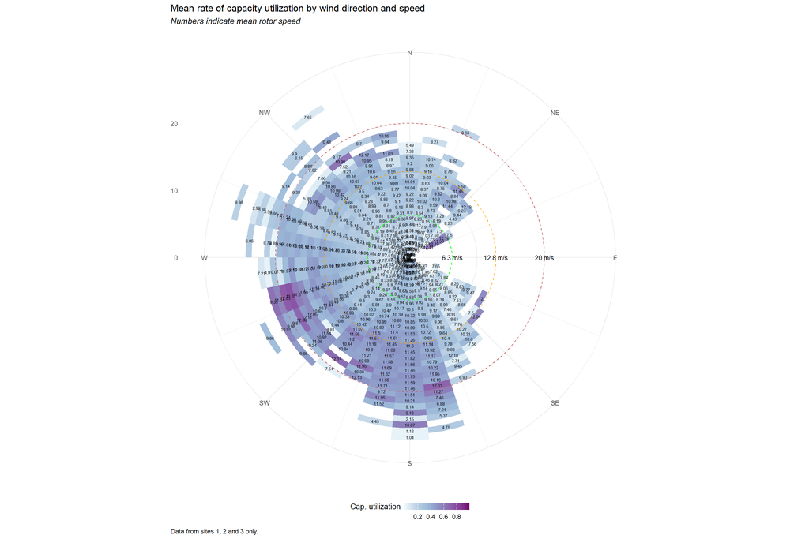

```r
panel_farms |>
  _[
    wind == TRUE & site != 4,
    ggplot(
      data = .SD
      ) +
      stat_summary_2d(
        mapping = aes(x = direction, y = wind_speed, z = cap_util),
        fun = "mean", fun.args = list(na.rm = TRUE)
        ) +
      stat_summary_2d(
        mapping = aes(label = round(after_stat(value), 2), x = direction, y = wind_speed, z = rotor_speed),
        fun = "mean", geom = "text", size = 2
        ) +
      geom_hline(
        yintercept = c(6.3, 12.8, 20), colour = c("green", "orange", "indianred"), linetype = "dashed"
        ) +
      geom_text(
        data = data.frame(label = c("6.3 m/s", "12.8 m/s", "20 m/s"), x = c(0, 0, 0), y = c(6.3, 12.8, 20)),
        mapping = aes(label = label, x = x, y = y),
        size = 3
        ) +
      scale_x_continuous(
        name = NULL,
        limits = c(0, 360),
        breaks = seq(from = 0, to = 315, by = 45),
        labels = cardinal_directions
        ) +
      coord_polar(
        start = 3 * pi / 2, direction = -1
        ) +
      scale_fill_distiller(
        name = "Cap. utilization", limits = c(0, 1), breaks = seq(.2, .8, .2), palette = "BuPu", direction = 1
        ) +
      labs(
        title = "Mean rate of capacity utilization by wind direction and speed",
        subtitle = "Numbers indicate mean rotor speed",
        caption = "Data from sites 1, 2 and 3 only.",
        y = NULL
        ) +
      theme_minimal() +
      theme(
        plot.title.position = "plot",
        plot.subtitle = element_text(face = "italic"),
        legend.position = "bottom",
        legend.key.height = rel(.5),
        legend.title = element_text(size = 10, vjust = 1),
        plot.caption.position = "plot",
        plot.caption = element_text(hjust = 0)
        )
    ]
```

## A Day In the Life of A Wind Farm

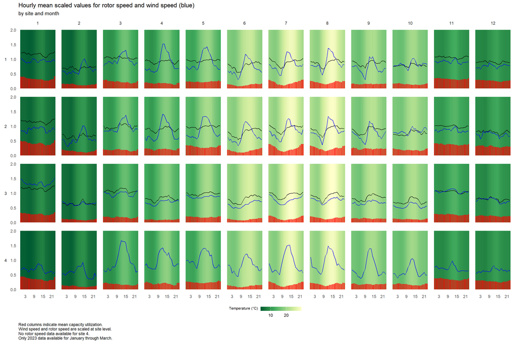

```r
copy(panel_farms) |>
  _[
    site == 4,
    rotor_speed := NA
    ] |>
  _[,
    `:=`(
      wind_speed = scale(wind_speed, center = FALSE),
      rotor_speed = scale(rotor_speed, center = FALSE)
      ),
    by = site
    ] |>
  _[,
    ggplot(
      data = .SD,
      mapping = aes(x = hour)
      ) +
      geom_rect(
        data = .SD[, list(temp = mean(temp, na.rm = TRUE)), by = list(site, month, hour)],
        mapping = aes(fill = temp, xmin = hour - .5, xmax = hour + .5, ymin = 0, ymax = 2)
        ) +
      stat_summary(
        mapping = aes(y = rotor_speed),
        fun = "mean", geom = "line"
        ) +
      stat_summary(
        mapping = aes(y = wind_speed),
        fun = "mean", geom = "line", colour = "blue"
        ) +
      stat_summary(
        mapping = aes(y = cap_util),
        fun = "mean", geom = "col", fill = "red", alpha = .7
        ) +
      scale_x_continuous(
        name = NULL, breaks = c(3, 9, 15, 21)
        ) +
      scale_y_continuous(
        name = NULL
        ) +
      scale_fill_distiller(
        name = "Temperature (°C)", palette = "YlGn", direction = -1
        ) +
      facet_grid(
        rows = vars(site), cols = vars(month), switch = "y"
        ) +
      labs(
        title = "Hourly mean scaled values for rotor speed and wind speed (blue)",
        subtitle = "by site and month",
        caption =
          paste0(
            "Red columns indicate mean capacity utilization.\n",
            "Wind speed and rotor speed are scaled at site level.\n",
            "No rotor speed data available for site 4.\n",
            "Only 2023 data available for January through March."
            )
        ) +
      theme_minimal() +
      theme(
        panel.grid = element_blank(),
        plot.caption = element_text(hjust = 0),
        strip.text.y.left = element_text(angle = 0),
        strip.placement = "outside",
        legend.key.height = rel(.5),
        legend.position = "bottom",
        legend.title = element_text(size = 8, vjust = 1)
        )
    ]
```

The wind farms are most efficient on November, December and January, regardless of the type. In contrast, February, June, August and October have the lowest capacity realization values. It is notable how generation profiles of the sites parallel each other, even with differing wind conditions and turbine designs. Capacity utilization remains below 50% for the most part, even in the case of site 2, which leads in terms of efficiency. Despite leading in overall power generation, site 3 realizes less of its capacity in comparison to the gearbox turbine farms.

Another thing that sets site 3 apart is weaker intra-day variability. Other sites experience a spike in wind speed in the noon for most of the year, coinciding with the increase in temperature. This is somehow accompanied by a decrease in power generation, even in the case of site 3 where such a shift is less pronounced. Rotor speed however is either unaffected or remains on an increasing trend. There are several possible explanations:

- Higher temperatures might be an operational constraint that impedes power output.
- Turbines might be better suited to exploit more stable winds, as hinted by the fact that weak variability in November and December is accompanied by strong generation, although wind speeds are also relatively high.
- With increased solar generation, the grid may refuse power output by wind farms. Alternatively, the producer might not schedule generation in anticipation of solar output.
- Power output is stored and dispatched later, for example during the uptick in the afternoon. This possibility would bring into question the methodology of data collection, and invalidate the findings of this report.

```r
panel_farms |>
  _[, list(`Time of Day` = time_of_day, `Total Power (kWh)` = sum(power, na.rm = TRUE)), by = time_of_day] |>
  _[, list(`Time of Day`, `Total Power (kWh)`, Proportion = round(`Total Power (kWh)` / sum(`Total Power (kWh)`), 2))]
```

```
##    Time of Day Total Power (kWh) Proportion
##          <ord>             <num>      <num>
## 1:    10AM-3PM          64339235       0.23
## 2:     4PM-9PM          69043813       0.24
## 3:    10PM-3AM          82377705       0.29
## 4:     4AM-9AM          69580696       0.24
```

Speaking of daily variability, for the observed time frame, generation is at its highest during the nighttime hours between 10PM and 3AM, and more or less evenly split among other periods with 10AM-3PM slightly behind. There seems to be a pattern of slight increase in wind speed in the evening, which disappears in the early hours of morning around the 3AM mark. The supply and demand profile may also be better suited for wind generation, with solar generation absent and base load facilities possibly reluctant to dispatch late into the night when demand is low. The slight decrease in 10AM-3PM is in line with the trends observed in above charts, although suggesting that the decrease may be less dramatic than it seems.

## Chasing the Wind

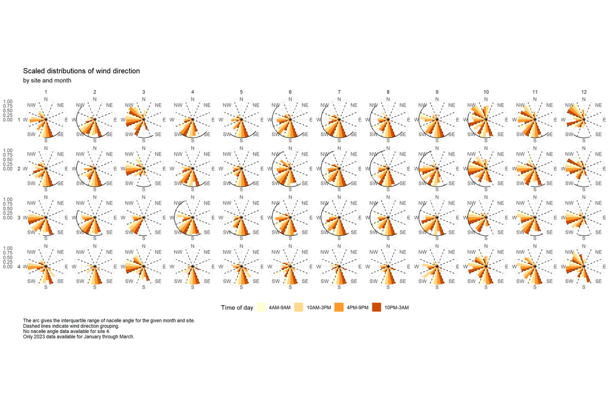

```r
panel_farms |>
  _[
    wind == TRUE,
    ggplot(
      data = .SD
      ) +
      geom_histogram(
        mapping = aes(x = direction, y = after_stat(ncount), fill = rev(time_of_day)), binwidth = 45, position = "dodge"
        ) +
      geom_segment(
        mapping = aes(x = V1, xend = V2, y = Inf),
        data = .SD[, list(quantile(angle, .25, na.rm = TRUE), quantile(angle, .75, na.rm = TRUE)), by = list(site, month)]
        ) +
      geom_vline(
        xintercept = seq(22.5, 337.5, by = 45), linetype = rep("dashed", 384)
        ) +
      scale_x_continuous(
        name = NULL,
        limits = c(0, 360),
        breaks = seq(from = 0, to = 315, by = 45),
        labels = cardinal_directions
        ) +
      scale_y_continuous(
        name = NULL, guide = NULL
        ) +
      scale_fill_brewer(
        name = "Time of day", palette = "YlOrBr"
        ) +
      labs(
        title = "Scaled distributions of wind direction",
        subtitle = "by site and month",
        caption =
          paste0(
            "The arc gives the interquartile range of nacelle angle for the given month and site.\n",
            "Dashed lines indicate wind direction grouping.\n",
            "No nacelle angle data available for site 4.\n",
            "Only 2023 data available for January through March."
            )
        ) +
      coord_polar(
        start = 3 * pi / 2, direction = -1
        ) +
      facet_grid(
        rows = vars(site), cols = vars(month), switch = "y"
        ) +
      theme_minimal() +
      theme(
        strip.text.y.left = element_text(angle = 0),
        plot.caption = element_text(hjust = 0),
        legend.position = "bottom"
        )
    ]
```

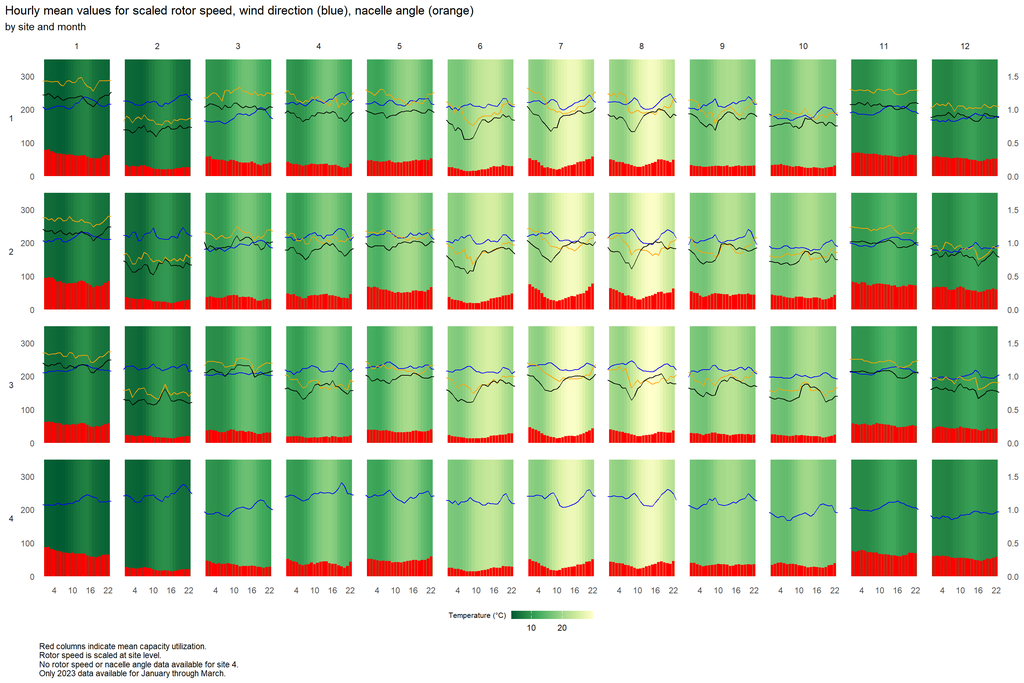

```r
copy(panel_farms) |>
  _[
    site == 4,
    c("rotor_speed", "angle") := NA
    ] |>
  _[,
    `:=`(
      wind_speed = scale(wind_speed, center = FALSE),
      rotor_speed = scale(rotor_speed, center = FALSE)
      ),
    by = site
    ] |>
  _[,
    ggplot(
      data = .SD,
      mapping = aes(x = hour)
      ) +
      geom_rect(
        data =
          .SD |>
          _[,
            list(temp = mean(temp, na.rm = TRUE)),
            by = list(site, month, hour)
            ],
        mapping = aes(xmin = hour - .5, xmax = hour + .5, ymin = 0, ymax = 350, fill = temp)
        #alpha = .8
        ) +
      stat_summary(
        mapping = aes(y = direction),
        fun = "mean", geom = "line", colour = "blue"
        ) +
      stat_summary(
        mapping = aes(y = angle),
        fun = "mean", geom = "line", colour = "orange"
        ) +
      stat_summary(
        mapping = aes(y = rotor_speed * 200),
        fun = "mean", geom = "line"
        ) +
      stat_summary(
        mapping = aes(y = cap_util * 200),
        fun = "mean", geom = "col", fill = "red"
        ) +
      scale_x_continuous(
        name = NULL, limits = c(0, 23), breaks = c(4, 10, 16, 22)
        ) +
      scale_y_continuous(
        name = NULL, limits = c(0, 350), sec.axis = sec_axis(transform = ~ . / 200)
        ) +
      scale_fill_distiller(
        name = "Temperature (°C)", palette = "YlGn", direction = -1
        ) +
      labs(
        title = "Hourly mean values for scaled rotor speed, wind direction (blue), nacelle angle (orange)",
        subtitle = "by site and month",
        caption =
          paste0(
            "Red columns indicate mean capacity utilization.\n",
            "Rotor speed is scaled at site level.\n",
            "No rotor speed or nacelle angle data available for site 4.\n",
            "Only 2023 data available for January through March."
            )
        ) +
      facet_grid(
        rows = vars(site), cols = vars(month), switch = "y"
        ) +
      theme_minimal() +
      theme(
        panel.grid = element_blank(),
        plot.title.position = "plot",
        plot.caption = element_text(hjust = 0),
        strip.text.y.left = element_text(angle = 0),
        strip.placement = "outside",
        legend.key.height = rel(.5),
        legend.position = "bottom",
        legend.title = element_text(size = 8, vjust = .9)
        )
    ]
```

Daily and monthly trends seem to confirm the management decision for maintaining a nacelle orientation ahead of wind direction. In the months of November, December and January, the angle remains constantly above wind direction, and the generation is strong throughout the day. In contrast, in February (2023) when generation is particularly low, nacelle is constantly oriented to remain behind wind direction counter-clockwise. Further supporting factors are the dips in summer months accompanied by lower generation. Interacting effects based on seasonality however can not be ruled out— similar angles are maintained in relation to wind direction in May and October in site 1, however the generation in May is much higher than that in October. August and September values also seem to be less impacted by this supposed interplay between nacelle orientation and wind direction.

```r
panel_farms |>
  _[,
    ggplot(
      data =
        copy(.SD) |>
        _[
          site != 4 & !is.na(wind_speed) & !is.na(cardinality)
          ] |>
        _[,
          diff := angle - direction
          ]
      ) +
      geom_point(
        mapping = aes(x = diff, y = cap_util, colour = site),
        shape = 20
        ) +
      geom_vline(
        xintercept = c(-180, -90, 90, 180), linetype = "dashed"
        ) +
      scale_x_continuous(
        name = "Difference", limits = c(-200, 200), breaks = c(-180, -90, 0, 90, 180)
        ) +
      scale_y_continuous(
        name = "Capacity utilization (0-1)", guide = NULL
        ) +
      scale_colour_brewer(
        name = "Site", palette = "Dark2", type = "qual"
        ) +
      facet_grid(
        rows = vars(cardinality),
        cols = vars(cut(wind_speed, breaks = 4, ordered_result = TRUE)),
        switch = "y"
        ) +
      labs(
        title = "Nacelle angle with the wind according to cardinality and wind speed (m/s)"
        ) +
      theme_minimal() +
      theme(
        panel.grid = element_blank(),
        plot.title.position = "plot",
        strip.text.y.left = element_text(angle = 0)
        )
    ] -> angle_dotplot
```

```r
panel_farms |>
  _[
    !is.na(cardinality),
    ggplot(
      data = .SD
      ) +
      stat_summary(
        mapping = aes(x = cardinality, y = power),
        fun = "sum", geom = "col", fill = "indianred"
        ) +
      facet_wrap(
        facets = vars(site), nrow = 2, axes = "all_x"
        ) +
      labs(
        title = "Total power generation (kWh) by cardinality",
        x = NULL,
        y = NULL
        ) +
      theme_minimal() +
      theme(
        panel.grid = element_blank()
        )
    ] -> cardinality_generation

panel_farms |>
  _[
    !is.na(cardinality) & site != 4,
    ggplot(
      data = .SD
      ) +
      stat_summary(
        mapping = aes(x = cardinality, y = angle - direction),
        fun = "median", geom = "col", fill = "orange"
        ) +
      scale_y_continuous(
        name = NULL, breaks = seq.int(-135, 135, by = 45)
        ) +
      facet_wrap(
        facets = vars(site), nrow = 2, axes = "all"
        ) +
      labs(
        title = "Nacelle angle with the wind (median) by cardinality",
        x = NULL,
        y = NULL
        ) +
      theme_minimal() +
      theme(
        panel.grid = element_blank()
        )
    ] -> cardinality_angle
```

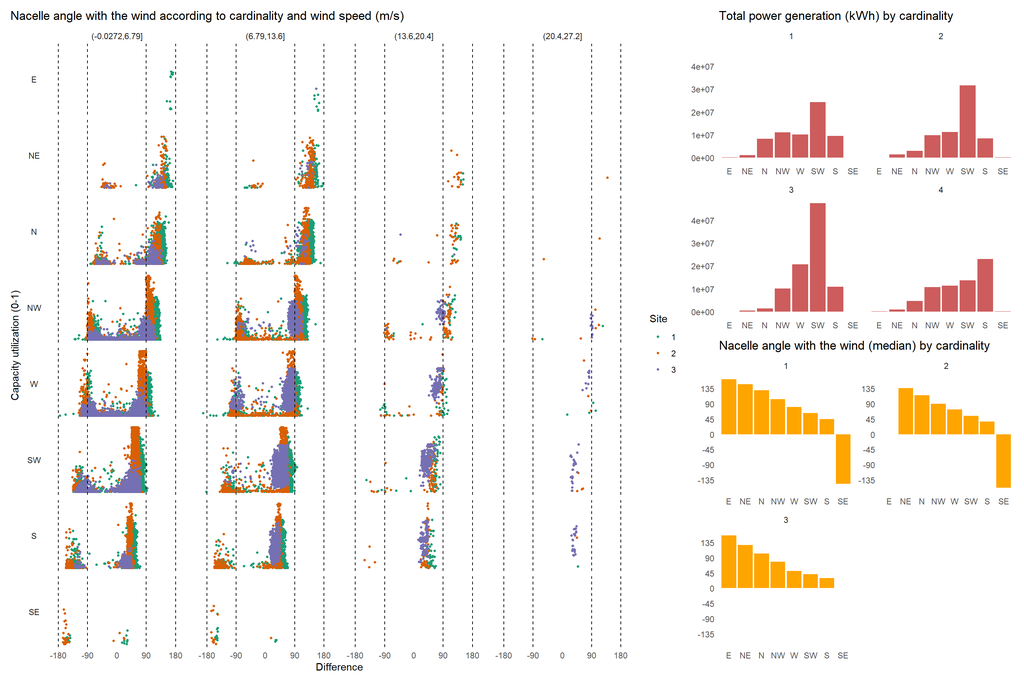

```r
angle_dotplot +
cardinality_generation +
cardinality_angle +
  plot_layout(
    design = c(area(1, 1, 2, 2), area(1, 3), area(2, 3))
    )
```

With all that said, it is clear that nacelle angle is far from being the only decisive factor for power generation, as evidenced by the fact that readings with similar nacelle angle values have power outputs ranging all over the spectrum. Nevertheless, we can say with some confidence that operators rely on and expect southwest winds regarding turbine orientation.

## Conclusion

We have investigated data from four European wind farms collected in the period of 2021-2023. By making aggregations on the basis of site, month, time of day and wind direction, we have examined power generation, capacity utilization, wind speed, rotor speed and nacelle angle values to better understand wind farm operation and efficiency. Noting the contrast between the sites in France and Spain, we have seen how their generation patterns and environmental conditions differ. Having established daily and seasonal trends, we found that power generation across sites remain similar, in spite of differences in efficiency, operational conditions and climate. We then observed nacelle angle values to look for patterns in operator decision-making, and asserted that operators generally anticipate southwest winds and do not act in a particularly reactive manner.

Based on this report, my current aims are as follows:

- Build a dashboard to enable a more hands-on look at the data.
- Simulate or model how the sites in France and Spain may behave in each other’s environmental conditions, to see if improvements are possible.
- Build a model for predicting high-output days as well as downtime.
- Investigate possible shortcomings in site 4 aside from weather conditions, keeping in mind its differing characteristics such as turbine count, capacity etc.

### References

1- Sánchez-Soriano, J.; Paniagua-Falo, P.J.; Gómez Muñoz, C.Q. Historical Hourly Information of Four European Wind Farms for Wind Energy Forecasting and Maintenance. Data 2025, 10, 38. https://doi.org/10.3390/data10030038